# Lab 10: Filtering Data

## Pick a dataset

Today you will again have a choice of three datasets to work with. You can choose either to investigate the daily team ELO ratings in the NBA:

Metadata from US senator’s tweets:

Or swear words given in the movies of Quentin Tarantino:

Pick a dataset (feel free to delete the others from the Rmd file if you would like), and work on the instructions in the next section.

## Instructions

This lab is similar to the last. You’ll pick a dataset and then generate an analysis of that data using data visualizations. The difference here is that instead of a single plot, I would like you to construct 3-4 plots that together tell a linear story. Each plot should be separated by a sentence or two describing what the viewer should take away from the plot. Try to keep the plots similar in some way; perhaps each simply highlights a different subset of the data but has the same underlying layers.

Notice that each of the datasets for today are larger than you will probably be able to use. You will need to filter the data to a particular team, year, subset of curse words. You may further filter the data to highlight an even smaller subset of the data within each plot.

## Analysis

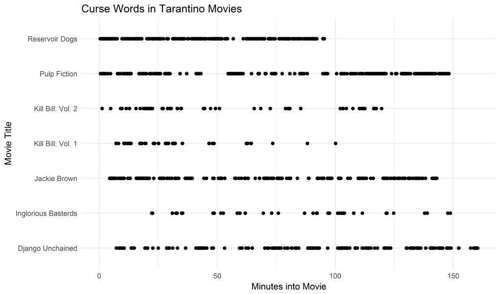

This is just the general plot of the swear words used throughout the movie by minutes in.

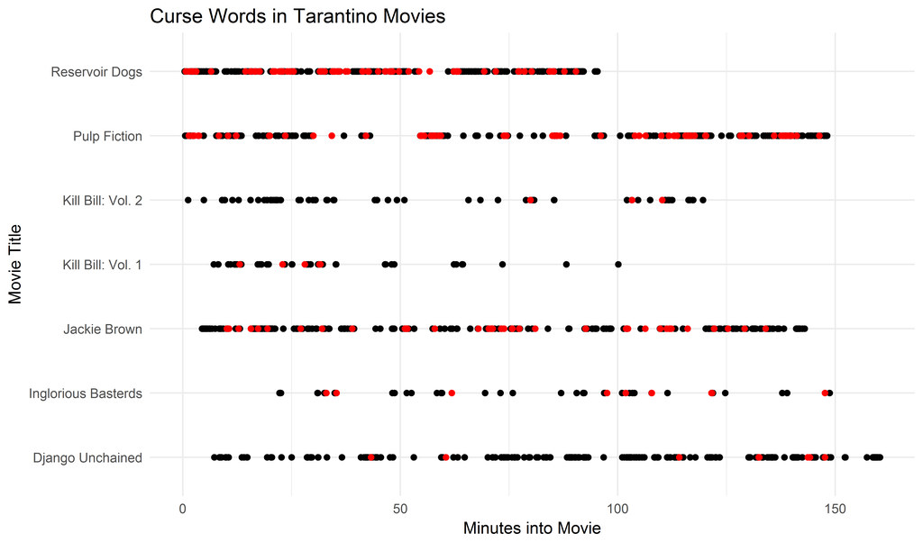

This shows the amount of times the word “fuck” is used. For Reservoir Dogs, it is used fairly throughout the movie, but the Kill Bill series does not use it as much.

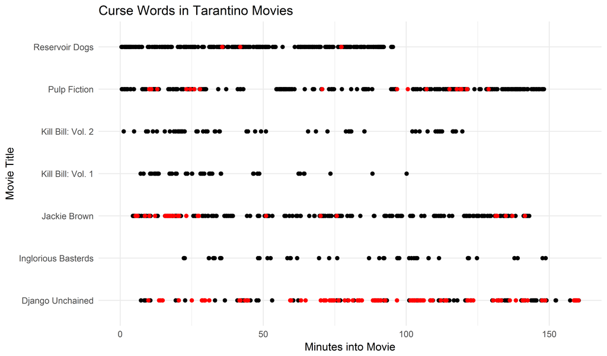

This shows the use of the n-word throughout the movies. This shows that in Kill Bill Vol. 1, which is set in Japan, has no use of the n-word. On the other hand, Django Unchanged, is set in the wild west.

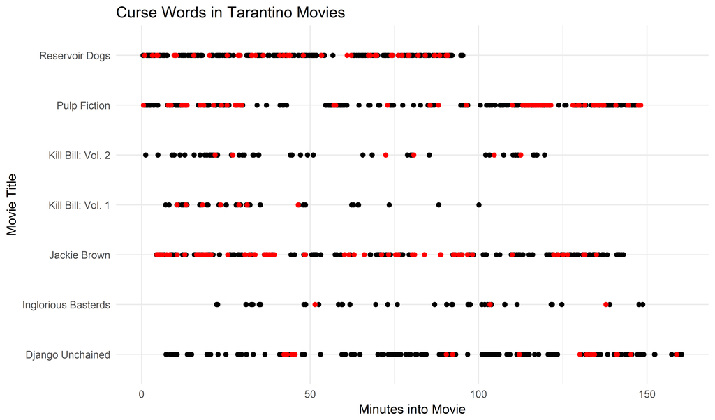

This plot shows the use of the word “shit” in the movies. It can be said that this is one of the most used words in the movies because of how versatile it is. The word can be used in many different cases and does not really have a specific meaning like other words such as “motherfucker” or “bitch”.